# Prediction Assignment

J Gregg

25/11/2020

## Partitioning the data

After loading the training data I began by partitioning the data into training and testing sets. Assigning 60% of the data to the training set

```r
data <- read.csv("./data/pml-training.csv")
set.seed(32345)
inTrain <- createDataPartition(y = data$classe, p = 0.6, list = FALSE)
training <- data[inTrain,]
testing <- data[-inTrain,]
```

```r
dim(training)
```

```
## [1] 11776   160
```

## Initial inspection

After inspecting the dimension of the data, the large number (160) of variables suggested it would be necessary to reduce the number of variables in the model. An inspection of the data revealed that a number of variables (particularly those associated with kurtosis and skewness) were predominantly NA’s and so these variables were removed from the data set. In addition parameters with a min or max prefix which appear to have a large number of #DIV/0! errors are removed.

```r
nas <- NULL
for (i in 1:160){
  numnas <- is.na(training[,i])
  nas[i]=sum(numnas)
}
training <- training[,nas==0]
training <- training[,c(8:11,21:42,49:51,61:73,83:93)]
training[1:52]  <- lapply(training[1:52], as.numeric)
```

## Principal Component analysis

It is apparent that there is a large degree of covariance between the variables

```r
M <- abs(cor(training[,-53]))
diag(M) <- 0
which(M >0.8,arr.ind=T)
```

```
##                  row col
## yaw_belt           3   1
## total_accel_belt   4   1
## accel_belt_y       9   1
## accel_belt_z      10   1
## accel_belt_x       8   2
## magnet_belt_x     11   2
## roll_belt          1   3
## roll_belt          1   4
## accel_belt_y       9   4
## accel_belt_z      10   4
## pitch_belt         2   8
## magnet_belt_x     11   8
## roll_belt          1   9
## total_accel_belt   4   9
## accel_belt_z      10   9
## roll_belt          1  10
## total_accel_belt   4  10
## accel_belt_y       9  10
## pitch_belt         2  11
## accel_belt_x       8  11
## magnet_belt_z     13  12
## magnet_belt_y     12  13
## gyros_arm_y       19  18
## gyros_arm_x       18  19
## magnet_arm_x      24  21
## accel_arm_x       21  24
## magnet_arm_z      26  25
## magnet_arm_y      25  26
## accel_dumbbell_x  34  28
## accel_dumbbell_z  36  29
## gyros_dumbbell_z  33  31
## gyros_forearm_z   46  31
## gyros_dumbbell_x  31  33
## gyros_forearm_z   46  33
## pitch_dumbbell    28  34
## yaw_dumbbell      29  36
## gyros_forearm_z   46  45
## gyros_dumbbell_x  31  46
## gyros_dumbbell_z  33  46
## gyros_forearm_y   45  46
```

Therefore I will process the data with principal component analysis. The screeplot below shows the variance explained by succesive princial components

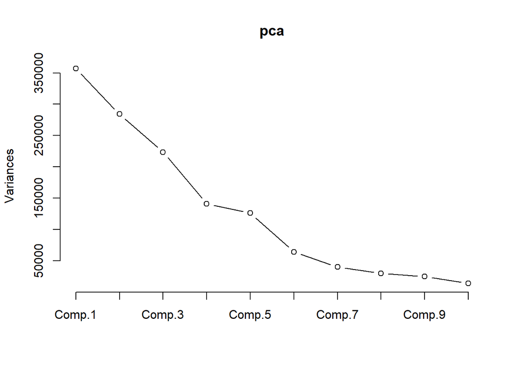

```r
pca <- princomp(training[,-53])
screeplot(pca,type="lines")
```

Based on the principal component analysis I decided to pre process using seven principal components. My pre processing also involved centering and scaling of data.

```r
trainingprocessed <- preProcess(training, method = c("center","scale","pca"), pcaComp = 7)
processeddata <- predict(trainingprocessed,training)
ctrl <- trainControl(method = "cv", number = 5)
model <- train(classe ~., method = "rf", data = processeddata, trainControl = ctrl)
preds <- predict(model,processeddata)
table(preds,training$classe)
```

```
##
## preds    A    B    C    D    E
##     A 3348    0    0    0    0
##     B    0 2279    0    0    0
##     C    0    0 2054    0    0
##     D    0    0    0 1930    0
##     E    0    0    0    0 2165
```

## Out-of-Sample Error

The predictions based on the training sample suggest an in-sample error of 0% (this is a concern as it suggests that the model is overfitted to the training data) I applied the same pre-processing to the testing data and applied the same model in order to judge the out-of-sample error

```r
processedtestingdata <- predict(trainingprocessed,testing)
preds <- predict(model,processedtestingdata)
table(preds,testing$classe)
```

```
##
## preds    A    B    C    D    E
##     A 2126   39   34   23   19
##     B   37 1392   78   11   35
##     C   42   55 1199   88   16
##     D   17   13   35 1149   25
##     E   10   19   22   15 1347
```

My estimate of the out of sample error based on using the model with the testing data is 8% (633/7846) and the details of my final model are as follows

## Model details

```r
model
```

```
## Random Forest
##
## 11776 samples
##     7 predictor
##     5 classes: 'A', 'B', 'C', 'D', 'E'
##
## No pre-processing
## Resampling: Bootstrapped (25 reps)
## Summary of sample sizes: 11776, 11776, 11776, 11776, 11776, 11776, ...
## Resampling results across tuning parameters:
##
##   mtry  Accuracy   Kappa
##   2     0.8860422  0.8557274
##   4     0.8803210  0.8484928
##   7     0.8641017  0.8279878
##
## Accuracy was used to select the optimal model using the largest value.
## The final value used for the model was mtry = 2.
```